# Module 06 - Séries chronologiques : synthèse

MQT-2101 - Analyse et modélisation des données

## Objectifs du module

- Préparer les données et définir la cible.
- Comparer aux références sur un futur simulé.
- Lire erreurs et incertitude.
- Choisir et suivre une méthode.

## 1. Définir une prévision utile

Quelle information faut-il pour préparer le suivi énergétique du prochain trimestre?

## Un tableau ordonné dans le temps

Transversal

Plusieurs unités, une période

Chronologique

Une quantité, plusieurs dates

## Le cas guidé

72

mois, de 2020 à 2025

1

bâtiment fictif

kWh

consommation mensuelle d’électricité

Données simulées. Une ligne représente un mois; aucun bâtiment réel n’est décrit.

## Origine, cible et horizon

Origine T

Dernière information disponible

Horizon h

Nombre de périodes à prévoir

$\widehat y_{T+h\mid T}$ : prévision de $y_{T+h}$ produite à l’origine $T$.

## Fréquence et granularité

Fréquence

Jour, semaine, mois

Granularité

Succursale, région, produit

## L’expertise complète les mesures

Opérations

Fermeture, chauffage, panne

Gestion

Occupation, horaires, travaux

## Le processus est une boucle

1

Cadrer et préparer

2

Comparer et choisir

3

Prévoir et suivre

## Préciser la décision

Énergie

Consommation et horizon mensuel

Budget

Tarifs et postes de facturation

Le coût d’une sous-prévision peut différer du coût d’une sur-prévision.

## 2. Lire les composantes d’une série

La hausse vient-elle du temps ou du calendrier?

## Respecter les axes

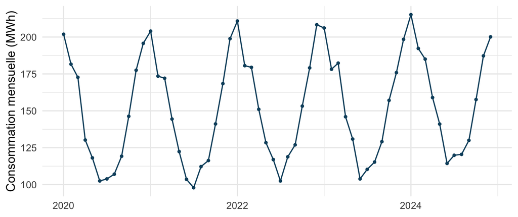

Explorer ici 2020 à 2024. Garder 2025 pour la validation.

## Niveau et tendance

Niveau

Valeur de référence locale

Tendance

Évolution persistante

## Saisonnalité, cycle et reste

Calendrier

motif de période connue

Cycle

fluctuation sans période fixe

Reste

variation non expliquée

## Additif ou multiplicatif?

Additif

$y_t=T_t+S_t+R_t$

Multiplicatif

$y_t=T_t\times S_t\times R_t$

$T_t$ regroupe ici niveau, tendance et cycle.

## Montant ou pourcentage?

+20 000 kWh

même amplitude à deux niveaux

+10 %

amplitude croissante avec le niveau

## Comparer les mêmes mois

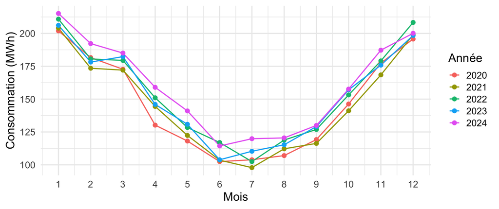

## Zoomer et changer d’échelle

```r
zoom <- apprentissage |> filter(date >= as.Date("2023-01-01"))
graphique_serie(zoom)
graphique_serie(apprentissage) + scale_y_log10()
```

## L’objet ts et la fenêtre

```r
serie <- ts(apprentissage$consommation_kwh, start = c(2020, 1), frequency = 12)
zoom_ts <- window(serie, start = c(2023, 1), end = c(2024, 12))
```

## Une tendance descriptive

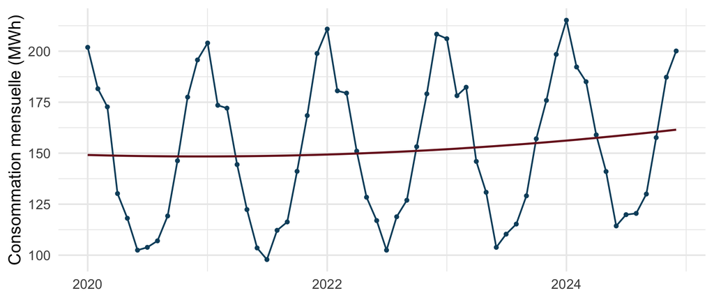

## 3. Préparer les données temporelles

Un mois absent peut-il être traité comme un mois observé?

Calendrier

doublons et périodes absentes

Mesure

NA, zéro, unités

Contexte

extrêmes et ruptures

## Mensuel ne signifie pas trente jours

```r
dates_attendues <- seq.Date(min(apprentissage$date),
                           max(apprentissage$date), by = "month")
setdiff(dates_attendues, apprentissage$date)
anyDuplicated(apprentissage$date)
```

## Valeur manquante ou période absente

Date présente, NA

La mesure manque

Date absente

Le calendrier a un trou

Retirer une ligne ne rend pas les périodes voisines consécutives.

## Imputer exige une règle

Historique

estimer avec l’information déjà disponible

Sensibilité

comparer plusieurs traitements

## Espacement irrégulier

Événements

arrivées à des heures variables

Agrégation

compte par jour ou semaine

## Extrême : erreur ou événement?

Erreur vérifiée

corriger et documenter

Événement réel

conserver ou modéliser le contexte

Sans justification, ne pas supprimer automatiquement.

## Combien d’années utiliser?

Historique long

davantage de répétitions

Historique récent

meilleure pertinence après une rupture

## Les variables externes arrivent-elles à temps?

Connues à l’origine

calendrier, fermeture planifiée

Inconnues

prix réalisé, demande future

## 4. Comparer des prévisions de référence

Une méthode élaborée fait-elle mieux qu’une règle simple?

## Bien ajuster n’est pas bien prévoir

Apprentissage

paramètres et structure

Validation

erreurs sur le futur simulé

## La séparation du cas guidé

60

mois d’apprentissage : 2020 à 2024

12

mois de validation : 2025

T

origine : décembre 2024

## Le naïf à origine fixe

$$\widehat y_{T+h\mid T}=y_T,\qquad h\geq1.$$

Une origine en décembre 2024. La dernière consommation mensuelle connue est répétée pour tous les mois de 2025.

## Le naïf saisonnier

$$\widehat y_{T+h\mid T}=y_{T+h-m},\qquad 1\leq h\leq m.$$

$m=12$ : reprendre les douze mois de la dernière année.

## Comparer sur les mêmes mois

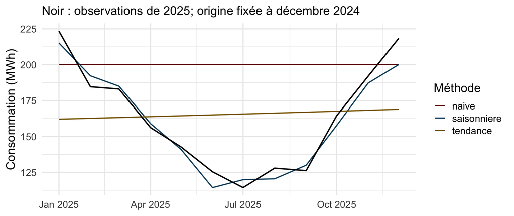

## Du code à la référence

```r
refs <- prevoir_references(apprentissage$consommation_kwh, horizon = 12, periode = 12)
validation |> mutate(naive = refs$naive,
                     saisonniere = refs$saisonniere)
```

## Choisir la période selon l’horizon

Un mois

répéter plusieurs origines à h = 1

Un an

évaluer aussi les horizons jusqu’à 12

## Réajuster avant la vraie prévision

1

Évaluer sur 2025

2

Fixer le choix

3

Réajuster sur 2020 à 2025

4

Prévoir 2026

## 5. Mesurer et lire les erreurs

Une erreur moyenne proche de zéro suffit-elle?

## Une convention de signe

$$e_{T+h}=y_{T+h}-\widehat y_{T+h\mid T}.$$

e > 0

sous-prévision

e < 0

sur-prévision

## ME, MAE et RMSE

$$\mathrm{ME}=\frac1n\sum e_i,\qquad\mathrm{MAE}=\frac1n\sum |e_i|.$$

$$\mathrm{RMSE}=\sqrt{\frac1n\sum e_i^2}.$$

Même unité que la cible. MAE est aussi appelée MAD.

## Les erreurs peuvent s’annuler

−20, +20

deux erreurs, en unités

ME = 0

aucun biais moyen ici

MAE = 20

erreur absolue persistante

RMSE = 20 également dans cet exemple.

## Le MAPE et ses limites

$$\mathrm{MAPE}=\frac{100}{n}\sum\left|\frac{e_i}{y_i}\right|.$$

Zéro : indéfini. Valeur proche de zéro : instabilité. Zéro arbitraire : pourcentage inadapté.

## La MASE : une échelle d’apprentissage

$$q_m=\frac{1}{T-m}\sum_{t=m+1}^{T}|y_t-y_{t-m}|,\qquad\mathrm{MASE}=\frac{\mathrm{MAE}_{\mathrm{validation}}}{q_m}.$$

$m=1$ : référence naïve. $m=12$ : référence saisonnière mensuelle.

## Que signifie MASE < 1?

Interprétation

MAE plus petite que q_m

Limite

pas une victoire garantie sur la validation

## Le résultat du cas guidé

| Méthode | ME (kWh) | MAE (kWh) | RMSE (kWh) | MAPE (%) | MASE |
| --- | --- | --- | --- | --- | --- |
| naive | -36 878,67 | 43 810,17 | 51 298,07 | 31,69 | 6,71 |
| saisonniere | 3 052,50 | 6 662,33 | 7 987,13 | 4,11 | 1,02 |
| tendance | -2 172,18 | 31 573,64 | 35 965,65 | 20,50 | 4,84 |

## Lire le temps et la distribution

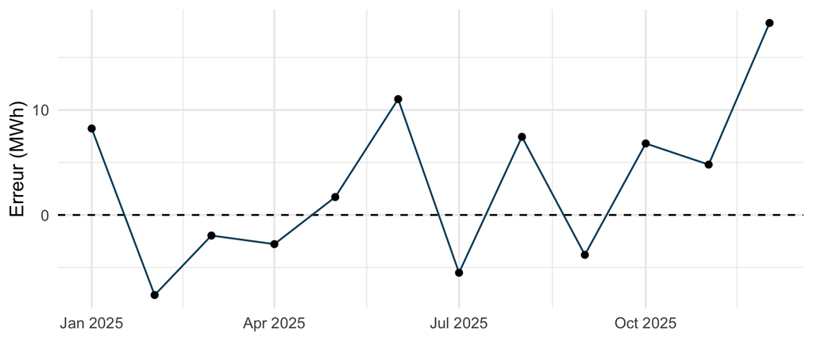

## 6. Communiquer l’incertitude

Une seule valeur suffit-elle au suivi énergétique?

## Un point et une plage

Point

Une valeur prévue

Intervalle

Une plage avec un niveau nominal

## Interpréter 95 %

Sur des répétitions comparables, une procédure calibrée à 95 % couvre la future observation dans environ 95 % des cas.

## Une approximation normale

$$\widehat y_{T+h\mid T}\ \pm\ 1{,}96\,\widehat\sigma_h.$$

Pour 95 %, si l’approximation normale et l’écart-type prédictif sont appropriés.

## Plus loin, plus incertain?

Niveau nominal plus élevé

intervalle généralement plus large

Horizon plus lointain

incertitude souvent accrue

## Lire un cône de prédiction

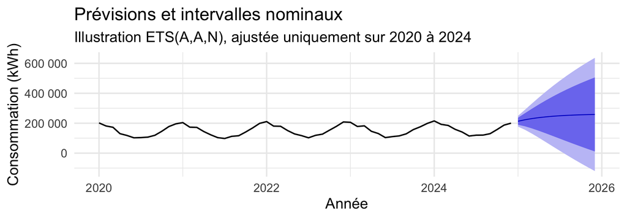

À h = 12, la borne à 95 % devient négative : limite du modèle pour une consommation d’énergie.

## Lire les trois lettres ETS

E

type d’erreur

T

type de tendance

S

type de saisonnalité

A : additif. M : multiplicatif. N : absence de tendance ou saisonnalité. Z : choix automatique dans forecast::ets().

## Comparer des cônes sans choisir à l’œil

ANN, AAN, AAA

trois structures illustratives

Validation

comparer erreurs et couverture

## Relier l’intervalle à une décision

Capacité

risque de dépassement

Budget

marge et scénario défavorable

## Complément A - Validation à plusieurs origines

Le choix reste-t-il bon à un mois et à six mois?

## Faire avancer l’origine

1

Déc. 2024 → janv. 2025

2

Janv. 2025 → févr. 2025

3

Févr. 2025 → mars 2025

## Fixe ou mobile?

Fixe

Douze horizons, une seule origine

Mobile

Un même horizon, plusieurs origines

## Combien de comparaisons?

h = 1

12 origines en 2025

h = 6

7 origines admissibles

h = 12

1 origine admissible

## Le geste à chaque origine

```r
origine <- 60
h <- 6
historique <- electricite$consommation_kwh[seq_len(origine)]
refs <- prevoir_references(historique, horizon = h)
erreur <- electricite$consommation_kwh[origine + h] - refs$naive[h]
```

## Comparer par horizon

| h | methode | n | ME | MAE | RMSE |
| --- | --- | --- | --- | --- | --- |
| 1 | naive | 12 | 1523.3 | 19989.0 | 23242.7 |
| 1 | saisonniere | 12 | 3052.5 | 6662.3 | 7987.1 |
| 6 | naive | 7 | -20973.9 | 63994.1 | 70792.8 |
| 6 | saisonniere | 7 | 5579.0 | 8235.6 | 9450.3 |

## Fenêtre croissante ou glissante

Croissante

conserver tout le passé disponible

Glissante

conserver un passé récent fixé

## Réévaluer sans recycler le test

1

Fixer les candidats

2

Comparer plusieurs origines

3

Retenir une méthode

4

Suivre les nouvelles erreurs

## Choisir selon la décision

Budget

horizon court et actualisation fréquente

Approvisionnement

horizon imposé par le délai

## Complément B - Familles de méthodes

Faut-il plus de complexité pour améliorer la décision?

## Structure explicite ou adaptation locale

Structure explicite

forme et paramètres d’un modèle

Adaptation locale

mémoire et pondération du passé

## Motif global et mémoire locale

Global dans une série

une structure sur toute la période

Local dans une série

une structure qui évolue

## Extrapoler ou utiliser des entrées?

Histoire de la cible

naïf, lissage, ARIMA

Informations externes

calendrier, météo, occupation

## Disponible au moment de prévoir

Calendrier futur

connu à l’origine

Prix réalisé futur

à prévoir ou scénariser

## Manuel, automatisé, surveillé

Automatiser

calcul et actualisation

Surveiller

erreurs, ruptures, qualité

## Combiner les prévisions

$$\widehat y^{\mathrm{comb}}=w\widehat y^{(1)}+(1-w)\widehat y^{(2)},\quad 0\leq w\leq1.$$

Exemple simple : moyenne à poids égaux, fixée avant la comparaison.

## Diversifier les erreurs

$$\operatorname{Var}(we_1+(1-w)e_2)=w^2\operatorname{Var}(e_1)+(1-w)^2\operatorname{Var}(e_2)+2w(1-w)\operatorname{Cov}(e_1,e_2).$$

Erreurs peu corrélées : diversification possible. Aucun gain garanti.

## Corriger en deux étapes

$\widehat y^{\mathrm{final}}=\widehat y^{\mathrm{base}}+\widehat e^{\mathrm{base}}$

Modèle de base → prévision de ses erreurs → correction

## La suite du cours

Module 7

lissage et comparaison

Module 8

tendance et saisonnalité

Module 9

variables externes et autocorrélation

## Produire un rapport reproductible

Une question, un calendrier vérifié, des graphiques, un protocole temporel, des erreurs et des limites.

## Référence

Hyndman, R. J., et Athanasopoulos, G. (2021). Forecasting: Principles and Practice, 3e édition.

Lectures ciblées et documentation